# Competencia ciencia de datos

Participante: Federico Baiocco

Email: baioccofede@gmail.com

# Introducción

Les presentamos a la empresa “Frío Frío”, dedicada a la venta e instalación de equipos de aire acondicionado para grandes superficies. Al ser una empresa B2B (“Business To Business”), es esencial para ellos optimizar los esfuerzos de los representantes comerciales, ayudándolos a priorizar las oportunidades en el pipeline.

Una “oportunidad” consiste en un proyecto de venta o instalación de equipos para un cliente. La venta se estructura alrededor de TRF (Toneladas de refrigeración) y puede estar compuesta por varios productos distintos. El "pipeline" hace referencia al flujo de oportunidades prospecto que la empresa está desarrollando. El equipo comercial asigna a distintos momentos, para cada oportunidad, un estado en la negociación. En la Ilustración se muestran los estados que las oportunidades tienen dentro del pipeline.

[figure not shown]

La variable que se está tratando de predecir es **“Probabilidad de éxito”** para cada oportunidad. ¿Cuál es la probabilidad de que la oportunidad se convierta en un caso Closed Won? El dataset cuenta con información de cada oportunidad, como por ejemplo información sobre el vendedor a cargo de la venta, información geográfica de los clientes, TRS pedidas, fecha prevista de entrega de los equipos, etc. A partir de dichas variables es posible entrenar un modelo que prediga para un tiempo futuro el éxito o fracaso de cada oportunidad. Idealmente, “Frío Frío” podrá usar este modelo para predecir la probabilidad de éxito de cada oportunidad comercial, para mejorar el rendimiento y optimizar el esfuerzo de los vendedores.

El objetivo de esta competencia es, en base a los datos de oportunidades históricas, predecir el éxito de todas las oportunidade comerciales surgidas en los últimos cuatro meses.

## Datos

Se entregan dos datasets:

- Entrenamiento con la variable objetivo.
- Validación, que es idéntico al primero, pero sin la variable objetivo.

El dataset de evaluación consiste en todas las oportunidades que fueron creadas en los últimos cuatro meses sobre los que se cuenta información.

## Descripción

### Diccionario de variables

- ID: id único del registro (Entero).
- Región: región de la oportunidad (Categórica).
- Territory: territorio comercial de la oportunidad (Categórica).
- Pricing, Delivery_Terms_Quote_Approval: variable que denomina si la oportunidad necesita aprobación especial de su precio total y los términos de la entrega (Binaria).
- Pricing, Delivery_Terms_Approved: variable que denomina si la oportunidad obtuvo aprobación especial de su precio total y los términos de la entrega (Binaria).
- Bureaucratic_Code_0_Approval: variable que denomina si la oportunidad necesita el código burocrático 0 (Binaria).
- Bureaucratic_Code_0_Approved: variable que denomina si la oportunidad obtuvo el código burocrático 0 (Binaria).
- Submitted_for_Approval: variable que denomina si fue entregada la oportunidad para la aprobación (Binaria).
- Bureaucratic_Code: códigos burocráticos que obtuvo la oportunidad (Categórica).
- Account_Created_Date: fecha de creación de la cuenta del cliente (Datetime).
- Source: fuente de creación de la oportunidad (Categórica).
- Billing_Country: país donde se emite la factura (Categórica).
- Account_Name: nombre de la cuenta del cliente (Categórica).
- Opportunity_Name: nombre de la oportunidad (Categórica).
- Opportunity_ID: id de la oportunidad (Entero).
- Sales_Contract_No: número de contrato (Entero).
- Account_Owner: vendedor del equipo comercial responsable de la cuenta cliente (Categórica).
- Opportunity_Owner: vendedor del equipo comercial responsable de la oportunidad comercial (Categórica).
- Account_Type: tipo de cuenta cliente (Categórica).
- Opportunity_Type: tipo de oportunidad (Categórica).
- Quote_Type: tipo de presupuesto (Categórica).
- Delivery_Terms: términos de entrega (Categórica).
- Opportunity_Created_Date: fecha de creación de la oportunidad comercial (Datetime).
- Brand: marca del producto (Categórica).
- Product_Type: tipo de producto (Categórica).
- Size: tamaño del producto (Categórica).
- Product_Category_B: categoría 'B' del producto (Categórica).
- Price: precio (Decimal).
- Currency: moneda (Categórica).
- Last_Activity: fecha de la última actividad (Datetime).
- Quote_Expiry_Date: fecha de vencimiento del presupuesto (Datetime).
- Last_Modified_Date: fecha de ultima modificación en la oportunidad (Datetime).
- Last_Modified_By: usuario responsable de la última modificación en la oportunidad (Categórica).
- Product_Family: familia de producto (Categórica).
- Product_Name: nombre del producto (Categórica).
- ASP_Currency: moneda del precio promedio (Categórica).
- ASP: (Average Selling Price) precio promedio a la venta (Decimal).
- ASP_(converted)_Currency: moneda del precio promedio convertido en la variable (Categórica)
- ASP_(converted): precio promedio a la venta convertido a otra moneda (Decimal).
- Planned_Delivery_Start_Date: límite inferior del rango previsto para la fecha de entrega (Datetime).
- Planned_Delivery_End_Date: límite superior del rango previsto para la fecha de entrega (Datetime).
- Month: mes-año de Planned_Delivery_Start_Date (Fecha).
- Delivery_Quarter: trimestre de Planned_Delivery_Start_Date (Categorica).
- Delivery_Year: año de Planned_Delivery_Start_Date (Fecha).
- Actual_Delivery_Date: fecha real de la entrega (Datetime).
- Total_Power: potencia del producto (Entero).
- Total_Amount_Currency: moneda del monto total (Decimal).
- Total_Amount: monto total (Decimal).
- Total_Taxable_Amount_Currency: moneda del monto gravado total (Categórica).
- Total_Taxable_Amount: monto gravado total (Categórica).
- Stage: variable target. Estado de la oportunidad (Categórica).
- Prod_Category_A: categoría 'A' del producto (Categórica).
- Total_Power_Discreet: categorización de la variable Total Power en bins (Categórica).

## Evaluación

La calificación de la competencia se logra, en un 50%, con el resultado de las predicciones. La métrica elegida para el set de validación es la función de Logistic Loss (Log Loss).

En el tablero se puede ver la evaluación de la solución propuesta en una muestra del set de validación. Esta muestra puede variar durante la competencia. El total del conjunto de datos de validación se reserva hasta el final de la competencia.

El 50% restante se obtiene presentando un informe donde se deberá explicar qué tratamiento hicieron en los datos y una explicación sobre el modelo propuesto. La nota la otorga un jurado ad-hoc de especialistas en el tema evaluando el informe.

Las predicciones se deben enviar en un archivo CSV sin encabezado conteniendo solamente la identificación de la oportunidad (Opportunity_ID) del dataset de valuación y la columna de predicciones (score). A continuación, se muestran tres filas de un archivo de predicciones típico:

Opportunity_ID, score

10689, 0.33

10690, 0.9853289

10691, 0.70956707

etc.

El jurado podrá requerir reproducir el puntaje correspondiente al último intento registrado en la competencia.

# Informe

A lo largo del informe se puede ver el análisis exploratorio de los datos realizado, el tratamiento que se realizó a las variables y algunos de los modelos que se decidió probar.

En principio, cuando realizaba el análisis exploratorio, vi que la variable Sales_Contract_No tenía muchos nulos y solamente con ver el nombre de la variable me sonaba que no tenía mucho sentido usarla para un modelo predictivo. Armé un modelo baseline, utilizando XGB Classifier, y al subir mi resultado veía que estaba MUY lejos de los que estaban primeros en la leaderboard, por lo que volví a analizar las variables 1 por 1 y encontré que la variable Sales_Contract_No estaba muy relacionada con el resultado final. Al armar un modelo incluyendo esta variable mi puntaje subió drásticamente y entraba dentro de los primeros 3 lugares de la leaderboard sin mucho esfuerzo. En ese momento, leí en la descripción de la competencia que había una trampa con una variable que causaba un problema conocido como target lekeage, y todo comenzó a tener sentido. Se puede ver en la sección del informe en la que pruebo distintos modelos, que al utilizar XGB incluyendo esa variable, el modelo le da una importancia enorme a la misma.

Al descartar esta variable, la competencia comenzo a parecerme más interesante y me hubiese encantado poder dedicarle más tiempo y entender mejor el significado de algunas variables o conocer más sobre el negocio, para poder realizar un mejor modelo predictivo. Por ejemplo, me hubiese gustado conocer el significado de los distintos "códigos burocraticos" y entender porque hay muchos casos en los que TRF es 0. Seguramente, teniendo un mejor entendimiento del negocio (algo muy importante en todo proyecto de ciencia de datos) podría haber tomado mejores deciciones y lograr un mejor puntaje.

Finalmente, despues de analizar y probar todo lo que pude en el tiempo que duro la competencia, decidí descartar las siguientes variables: *'Opportunity_ID','Last*Activity','ASP*(converted)_Currency','Quote_Type','Delivery_Quarter','Source','Account_Created_Date','ASP','Last_Modified_Date','Actual_Delivery_Date', 'Sales_Contract_No','TRF','Total_Amount_Currency','Month','Delivery_Year','Territory','Submitted_for_Approval', 'Brand','Currency', 'Quote_Expiry_Date','Total_Taxable_Amount_Currency','Opportunity_Name','Billing_Country','ASP*Currency', 'ASP*(converted)', 'Prod_Category_A','Product_Family','Price','Size','ID','Planned_Delivery_End_Date','Account_Name','Delivery_Terms','Product_Type'*

De todas estas variables, particularmente me hubiese gustado poder hacer un mejor análisis e incluir *ASP_(converted)*, y *TRF*. En principio probe también utilizar las variables *Product_Family* y *Product_Type* en lugar del nombre del producto, pero incluir el nombre del producto en lugar de estas variables me llevó a mejores resultados. En cuanto a las variables *Month, Delivery_Year y Delivery_Quarter* no las utilicé directamente, pero las calculé a partir de las fechas de entrega para asegurarme de estar utilizando valores correctos. Capaz esto no hacia falta, pero no tuve tiempo para comprobarlo.

Otras variables como ID, Opportunity_ID, etc las descarté desde un principio ya que son identificadores que no parecen tener mucha influencia sobre el resultado final.

Para hacer encoding de las variables categóricas, probé utlizar OneHotEncoder, LabelEncoder, en distintas variables. Sin embargo, finalmente lo que mejor resultado dió fue utilizar el TargetEncoder de la librería category_encoders. (http://contrib.scikit-learn.org/category_encoders/targetencoder.html)

En cuanto a los modelos, se probaron distintos modelos como se puede ver en el informe, desde modelos simples como Log Regression hasta algunos más poderosos como XGB. También se probó hacer distintos ensembles de modelos, de todas formas, el mejor resultado se obtuvo utilizando Adaboost. Me gustaría seguir mejorando en esta parte, ajustando hiperparámetros y armando algún modelo más poderoso que no se overfitee tanto.

Para seleccionar los distintos hiperparámetros en algunos casos hice gridSearch, en otros fue mas prueba-error por cuestiones de tiempo.

En conclusión, me pareció interesante participar de esta competencia, me gustan mucho este tipo de desafíos para seguir aprendiendo y por más de que la competencia haya finalizado seguiré intentado mejorar los resultados analizando mejor cada una de las variables, poniendo un mayor esfuerzo en la parte de feature engineering para poder incluir variables como TRF y ASP_(converted). De todas formas, por más de que quede mucho trabajo por hacer, un modelo como este o el que hayan desarrollado los distintos participantes de la competencia aporta mucho valor a el cliente para poder priorizar las distintas oportunidades de negocio. Me parece excelente que se invierta tiempo, dinero y otros recursos en explotar los datos que se tienen siempre que sea para aportar valor al negocio y simplificar u optimizar distintas tareas.

```python
import pandas as pd
import numpy as np
import matplotlib.pyplot as plt
import seaborn as sns
import warnings
from datetime import datetime, timedelta
from xgboost import XGBClassifier
from sklearn.metrics import log_loss, accuracy_score
from category_encoders.target_encoder import TargetEncoder
from sklearn.model_selection import train_test_split
from sklearn.base import BaseEstimator, TransformerMixin
from sklearn.pipeline import FeatureUnion, Pipeline
warnings.filterwarnings('ignore')
pd.set_option('display.max_columns', None)
pd.set_option('display.max_rows', None)
```

```python
date_cols = ['Account_Created_Date',
            'Opportunity_Created_Date',
            'Last_Activity',
            'Quote_Expiry_Date',
            'Last_Modified_Date',
            'Planned_Delivery_Start_Date',
            'Planned_Delivery_End_Date']
df = pd.read_csv('./data/train.csv', parse_dates=date_cols)
val = pd.read_csv('./data/val.csv', parse_dates=date_cols)
```

# Helper functions

```python
def calc_prevalence(y):
    return (sum(y)/len(y))
```

```python
def miss_data(df, miss_value):
    x = ['variable','cantidad', 'porcentaje']
    missing_data = pd.DataFrame(columns=x)
    columns = df.columns
    for col in columns:
        icolumn_name = col
        imissing_data = df[df[col]==miss_value].shape[0]
        imissing_in_percentage = (df[df[col]==miss_value].shape[0]/df[col].shape[0])*100
        missing_data.loc[len(missing_data)] = [icolumn_name, imissing_data, imissing_in_percentage]
    return missing_data.set_index('variable').sort_values(by='porcentaje',ascending=False)
```

# Análisis exploratorio de los datos

```python
df.info()
```

```
<class 'pandas.core.frame.DataFrame'>
RangeIndex: 16947 entries, 0 to 16946
Data columns (total 52 columns):
 #   Column                              Non-Null Count  Dtype
---  ------                              --------------  -----
 0   ID                                  16947 non-null  int64
 1   Region                              16947 non-null  object
 2   Territory                           16947 non-null  object
 3   Pricing, Delivery_Terms_Quote_Appr  16947 non-null  int64
 4   Pricing, Delivery_Terms_Approved    16947 non-null  int64
 5   Bureaucratic_Code_0_Approval        16947 non-null  int64
 6   Bureaucratic_Code_0_Approved        16947 non-null  int64
 7   Submitted_for_Approval              16947 non-null  int64
 8   Bureaucratic_Code                   16947 non-null  object
 9   Account_Created_Date                16947 non-null  datetime64[ns]
```

[output cut: 44 more lines]

## Faltantes

¿Qué columnas tienen valores faltantes?

```python
nulls = pd.DataFrame(df.isnull().sum().sort_values(ascending=False), columns=['nulls'])
nulls['porcentaje'] = round(100*nulls['nulls'] / len(df), 2)
nulls[nulls.nulls > 0]
```

|  | nulls | porcentaje |
| --- | --- | --- |
| Last_Activity | 16947 | 100.00 |
| Quote_Expiry_Date | 4625 | 27.29 |
| ASP_(converted) | 3209 | 18.94 |
| ASP | 3209 | 18.94 |
| Planned_Delivery_End_Date | 75 | 0.44 |
| Total_Amount | 59 | 0.35 |

```python
Nat_amount = miss_data(df, 'NaT')
Nat_amount[Nat_amount.cantidad > 0]
```

| variable | cantidad | porcentaje |
| --- | --- | --- |
| Actual_Delivery_Date | 16947 | 100.0 |

```python
None_amount = miss_data(df, 'None')
None_amount[None_amount.cantidad > 0]
```

| variable | cantidad | porcentaje |
| --- | --- | --- |
| Currency | 16052 | 94.718829 |
| Price | 15982 | 94.305777 |
| Size | 15967 | 94.217266 |
| Product_Type | 15935 | 94.028442 |
| Product_Category_B | 15928 | 93.987136 |
| Brand | 15911 | 93.886824 |
| Source | 9497 | 56.039417 |
| Sales_Contract_No | 6973 | 41.145926 |
| Territory | 4999 | 29.497846 |
| Account_Type | 112 | 0.660884 |
| Billing_Country | 27 | 0.159320 |

En el dataset se encontraron 3 tipos de valores faltantes:

- np.nan
- 'None'
- 'NaT'

## Target (Stage)

La variable a predecir es Stage. Queremos predecir la probabilidad de que una oportunidad se convierta en "Closed Won" o "Closed Lost"

```python
target_name = 'Stage'
target_map = {'Closed Won': 1, 'Closed Lost':0}
df[target_name].value_counts()
```

```
Closed Won       9533
Closed Lost      7350
Proposal           35
Negotiation        18
Qualification      11
Name: Stage, dtype: int64
```

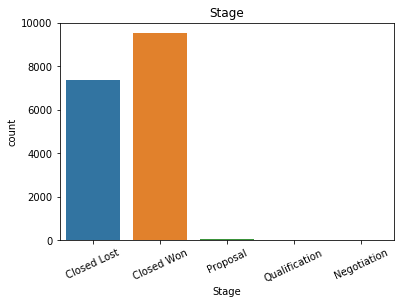

```python
g = sns.countplot(x='Stage', data=df)
plt.xticks(rotation=25)
plt.title('Stage')
plt.show()
```

En principio, nos interesa analizar las oportunidades de negocio que ya finalizaron, es decir, que están en estado "Closed Lost" o "Closed Won"

```python
interest_stages = ['Closed Won', 'Closed Lost']
```

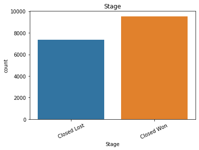

```python
g = sns.countplot(x='Stage', data=df[df.Stage.isin(interest_stages)])
plt.xticks(rotation=25)
plt.title('Stage')
plt.show()
```

```python
df[df.Stage == 'Closed Won'].shape[0] / df.shape[0]
```

```
0.5625184398418599
```

```python
df[df.Stage == 'Closed Lost'].shape[0] / df.shape[0]
```

```
0.43370508054522927
```

Tenemos un 56% de oportunidades que terminaron en Closed Won.

## Tipo de variables

Análisis de los distintos tipos de variables

### Variables categóricas

```python
categorical = [col for col in df.columns if (df[col].dtypes == 'object') & (col != target_name)]
```

```python
len(categorical)
```

```
31
```

Tenemos 31 variables categóricas. Vemos su cardinalidad:

```python
card = pd.DataFrame(df[categorical].nunique(), columns=['cardinalidad'])
```

```python
card.sort_values(by='cardinalidad', ascending = False)
```

|  | cardinalidad |
| --- | --- |
| Opportunity_Name | 9841 |
| Sales_Contract_No | 5267 |
| Account_Name | 1635 |
| Product_Name | 456 |
| Product_Family | 227 |
| Billing_Country | 80 |
| Territory | 76 |
| Last_Modified_By | 55 |
| Opportunity_Owner | 53 |
| Price | 53 |
| Month | 53 |
| Account_Owner | 48 |
| Product_Category_B | 28 |
| Brand | 26 |
| Opportunity_Type | 25 |
| Source | 14 |
| Delivery_Terms | 9 |
| Size | 7 |
| Account_Type | 7 |
| Bureaucratic_Code | 7 |
| Product_Type | 7 |
| Total_Taxable_Amount_Currency | 5 |
| Total_Amount_Currency | 5 |
| Region | 5 |
| ASP_Currency | 5 |
| Delivery_Quarter | 4 |
| Currency | 3 |
| Quote_Type | 2 |
| ASP_(converted)_Currency | 1 |
| Actual_Delivery_Date | 1 |
| Prod_Category_A | 1 |

Tenemos algunas variables categóricas de muy alta cardinalidad como Opportunity_Name que puede ser una especie de ID, Sales_Contract_No, Account_Name, Product_Name y Product*Family. Otras como ASP*(converted)_Currency, Actual_Delivery_Date y Prod_Category_A no aportan nada ya que tienen siempre el mismo valor.

```python
df.Quote_Type.value_counts()
```

```
Non Binding    16777
Binding          170
Name: Quote_Type, dtype: int64
```

En este caso, Quote type es en casi todos sus casos Non Binding, vemos si hay alguna tendencia en esos 170 casos Binding:

```python
df[df.Quote_Type == 'Binding'].Stage.value_counts()
```

```
Closed Won     86
Closed Lost    84
Name: Stage, dtype: int64
```

Quote Type no parece aportar nada.

```python
df[['Opportunity_Name']].head()
```

|  | Opportunity_Name |
| --- | --- |
| 0 | Opportunity_Name_12598 |
| 1 | Opportunity_Name_12600 |
| 2 | Opportunity_Name_469 |
| 3 | Opportunity_Name_415 |
| 4 | Opportunity_Name_851 |

```python
df[['Sales_Contract_No']].head()
```

|  | Sales_Contract_No |
| --- | --- |
| 0 | None |
| 1 | 39 |
| 2 | 760 |
| 3 | None |
| 4 | None |

```python
df[['Account_Name']].head()
```

|  | Account_Name |
| --- | --- |
| 0 | Account_Name_619 |
| 1 | Account_Name_619 |
| 2 | Account_Name_1794 |
| 3 | Account_Name_1201 |
| 4 | Account_Name_1201 |

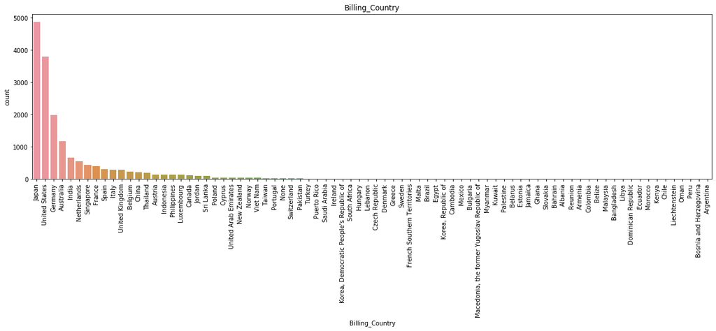

```python
plt.figure(figsize=(20,5))
sns.countplot(df['Billing_Country'], order = df['Billing_Country'].value_counts().index)
plt.title('Billing_Country')
plt.xticks(rotation=90)
plt.show()
```

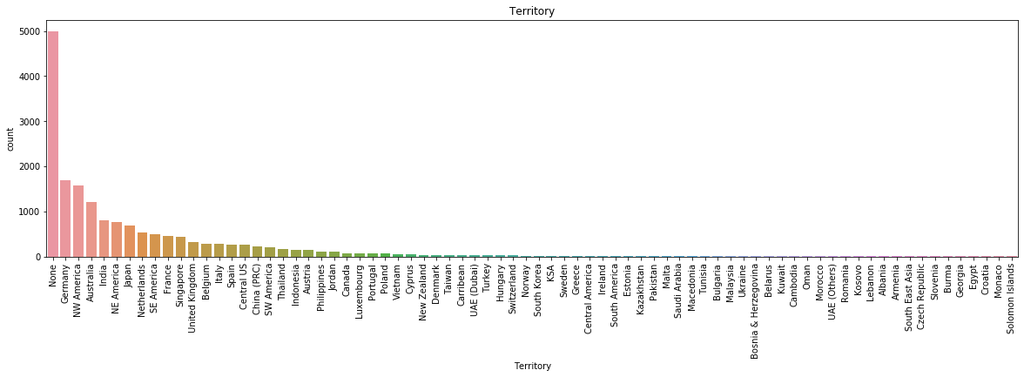

```python
plt.figure(figsize=(20,5))
sns.countplot(df['Territory'], order = df['Territory'].value_counts().index)
plt.title('Territory')
plt.xticks(rotation=90)
plt.show()
```

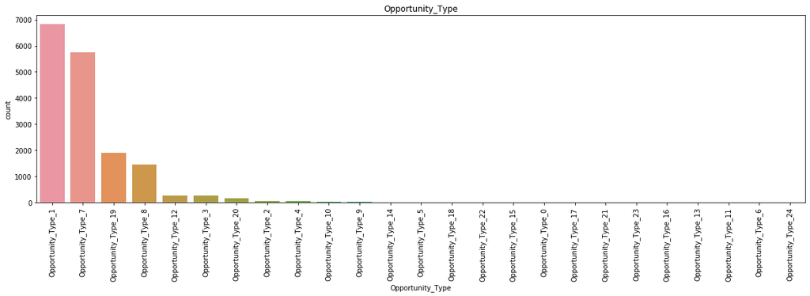

```python
plt.figure(figsize=(20,5))
sns.countplot(df['Opportunity_Type'], order = df['Opportunity_Type'].value_counts().index)
plt.title('Opportunity_Type')
plt.xticks(rotation=90)
plt.show()
```

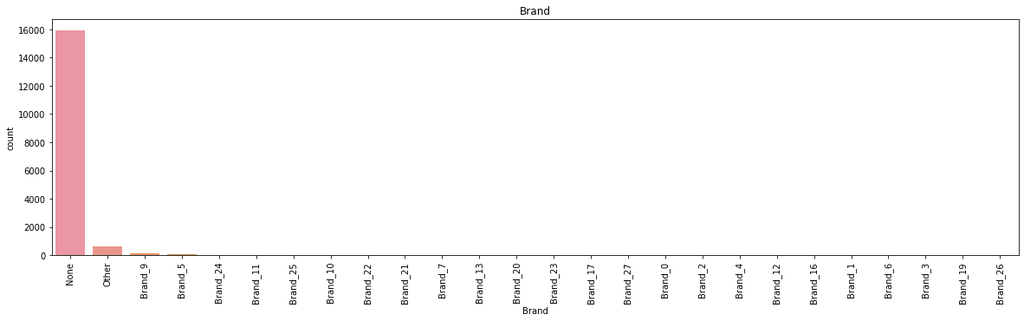

```python
plt.figure(figsize=(20,5))
sns.countplot(df['Brand'], order = df['Brand'].value_counts().index)
plt.title('Brand')
plt.xticks(rotation=90)
plt.show()
```

La mayor parte de estas variables tienen long tail. En algunos casos como Brand o Territory tenemos muchos valores faltantes.

Ahora veamos algunas de las variables con cardinalidad menor:

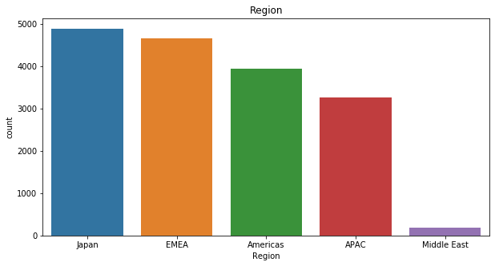

```python
plt.figure(figsize=(10,5))
sns.countplot(df['Region'], order = df['Region'].value_counts().index)
plt.title('Region')
plt.xticks(rotation=0)
plt.show()
```

Hay alguna relación entre la **región y el stage?** Alguna de las regiones es mas propensa a terminar en Closed Won o Closed Lost?

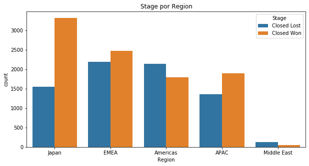

```python
plt.figure(figsize=(10,5))
sns.countplot(df[df.Stage.isin(interest_stages)]['Region'], order = df[df.Stage.isin(interest_stages)]['Region'].value_counts().index, hue=df[df.Stage.isin(interest_stages)].Stage)
plt.title('Stage por Region')
plt.xticks(rotation=0)
plt.show()
```

```python
region_analysis = df[['Region','Stage']]
region_analysis['Stage'] = region_analysis['Stage'].map(target_map)
region_analysis = region_analysis.dropna()
region_prevalence = pd.DataFrame(region_analysis.groupby('Region').apply(lambda g: calc_prevalence(g.Stage.values)), columns=['Prevalence'])
region_prevalence.sort_values(by='Prevalence', ascending=False)
```

| Region | Prevalence |
| --- | --- |
| Japan | 0.682481 |
| APAC | 0.583205 |
| EMEA | 0.530258 |
| Americas | 0.455886 |
| Middle East | 0.294118 |

Las distintas regiones parecen tener distintas tendencias. Veamos los distintos **Bureaucratic_Code:**

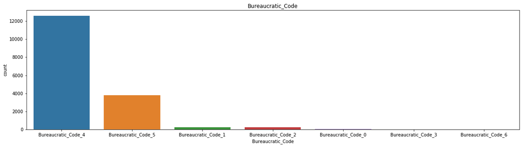

```python
plt.figure(figsize=(20,5))
sns.countplot(df['Bureaucratic_Code'], order = df['Bureaucratic_Code'].value_counts().index)
plt.title('Bureaucratic_Code')
plt.xticks(rotation=0)
plt.show()
```

```python
df.Bureaucratic_Code.value_counts()
```

```
Bureaucratic_Code_4    12587
Bureaucratic_Code_5     3803
Bureaucratic_Code_1      261
Bureaucratic_Code_2      242
Bureaucratic_Code_0       51
Bureaucratic_Code_3        2
Bureaucratic_Code_6        1
Name: Bureaucratic_Code, dtype: int64
```

Tenemos muy pocos casos de Bureaucratic_Code 0, 3 y 6. Veamos que hay en los de Bureaucratic_Code_0 que son solo 51:

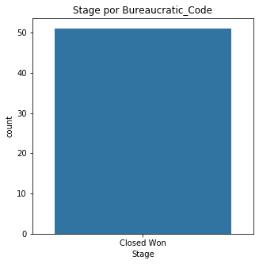

```python
plt.figure(figsize=(5,5))
sns.countplot(df[df.Bureaucratic_Code == 'Bureaucratic_Code_0']['Stage'])
plt.title('Stage por Bureaucratic_Code')
plt.xticks(rotation=0)
plt.show()
```

Son solo 51 casos los que tienen el Bureaucratic_Code_0, pero todos terminaron en closed won, esto podría llegar a significar algo. Tenemos una variable "Bureaucratic_Code_0_Approved" y otra "Bureaucratic_Code_0_Approval". Las analizaremos más adelante. Ahora vemos si hay alguna tendencia en el resto de los Bureaucratic_Code:

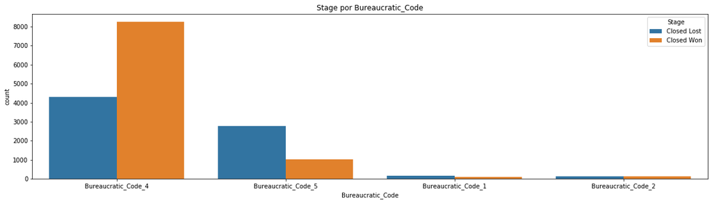

```python
relevant_bc = ['Bureaucratic_Code_4','Bureaucratic_Code_5','Bureaucratic_Code_1','Bureaucratic_Code_2']
bc_analysis = df[['Bureaucratic_Code','Stage']]
bc_analysis = bc_analysis[(bc_analysis['Stage'].isin(interest_stages)) & bc_analysis['Bureaucratic_Code'].isin(relevant_bc)]
plt.figure(figsize=(20,5))
sns.countplot(bc_analysis['Bureaucratic_Code'], hue=bc_analysis.Stage)
plt.title('Stage por Bureaucratic_Code')
plt.xticks(rotation=0)
plt.show()
```

```python
bc_analysis.Stage = bc_analysis.Stage.map(target_map)
bc_prevalence = pd.DataFrame(bc_analysis.groupby('Bureaucratic_Code').apply(lambda g: calc_prevalence(g.Stage.values)), columns=['Prevalence'])
bc_prevalence.sort_values(by='Prevalence', ascending=False)
```

| Bureaucratic_Code | Prevalence |
| --- | --- |
| Bureaucratic_Code_4 | 0.657924 |
| Bureaucratic_Code_2 | 0.471074 |
| Bureaucratic_Code_1 | 0.390805 |
| Bureaucratic_Code_5 | 0.267319 |

Tenemos muy pocos casos para afirmar que pasa algo con los Bureaucratic Code 1, 2 y 0. Pero se puede ver que en el 4 hay una tendencia a Closed Won y en el 5 a Closed Lost.

Ahora, los tipos de productos tendrán alguna relación con el Stage?

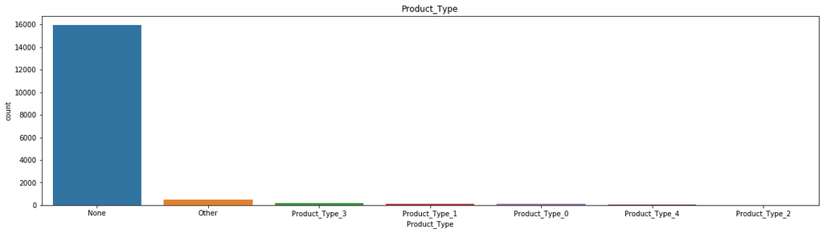

```python
plt.figure(figsize=(20,5))
sns.countplot(df['Product_Type'], order = df['Product_Type'].value_counts().index)
plt.title('Product_Type')
plt.xticks(rotation=0)
plt.show()
```

No tenemos mucha información de los tipos de productos. No podemos responder esta pregunta.

Vemos si las variables **Bureaucratic_Code_0_Approved** y **Bureaucratic_Code_0_Approval** afectan el resultado:

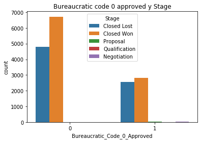

```python
sns.countplot(df.Bureaucratic_Code_0_Approved, hue=df.Stage)
plt.title("Bureaucratic code 0 approved y Stage")
plt.show()
```

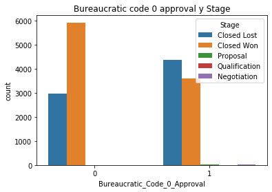

```python
sns.countplot(df.Bureaucratic_Code_0_Approval, hue=df.Stage)
plt.title("Bureaucratic code 0 approval y Stage")
plt.show()
```

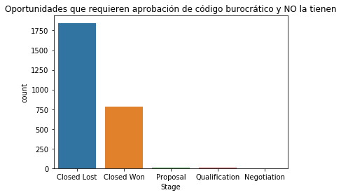

```python
sns.countplot(df[(df.Bureaucratic_Code_0_Approved == 0) & (df.Bureaucratic_Code_0_Approval == 1)].Stage)
plt.title("Oportunidades que requieren aprobación de código burocrático y NO la tienen")
plt.show()
```

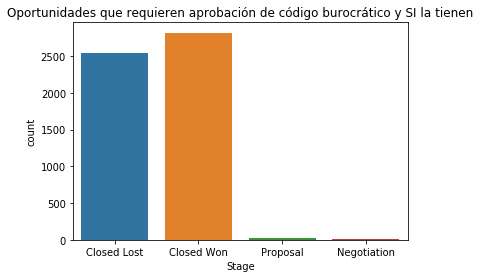

```python
sns.countplot(df[(df.Bureaucratic_Code_0_Approved == 1) & (df.Bureaucratic_Code_0_Approval == 1)].Stage)
plt.title("Oportunidades que requieren aprobación de código burocrático y SI la tienen")
plt.show()
```

No sabemos el significado real de el código burocrático 0 a nivel negocio, pero vemos que cuando necesita aprobación y no la tiene, es propenso a terminar en closed lost.

Analizamos **Pricing, Delivery_Terms_Quote_Appr** y **Pricing, Delivery_Terms_Approved**

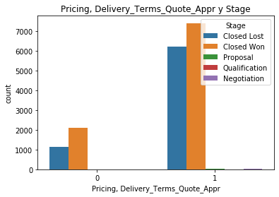

```python
sns.countplot(df['Pricing, Delivery_Terms_Quote_Appr'], hue=df.Stage)
plt.title("Pricing, Delivery_Terms_Quote_Appr y Stage")
plt.show()
```

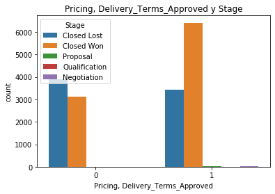

```python
sns.countplot(df['Pricing, Delivery_Terms_Approved'], hue=df.Stage)
plt.title("Pricing, Delivery_Terms_Approved y Stage")
plt.show()
```

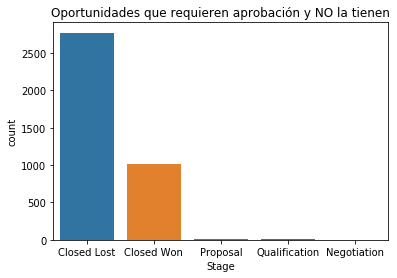

```python
sns.countplot(df[(df['Pricing, Delivery_Terms_Approved'] == 0) & (df['Pricing, Delivery_Terms_Quote_Appr'] == 1)].Stage)
plt.title("Oportunidades que requieren aprobación y NO la tienen")
plt.show()
```

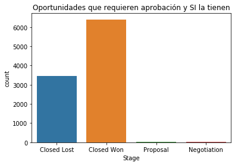

```python
sns.countplot(df[(df['Pricing, Delivery_Terms_Approved'] == 1) & (df['Pricing, Delivery_Terms_Quote_Appr'] == 1)].Stage)
plt.title("Oportunidades que requieren aprobación y SI la tienen")
plt.show()
```

Esta variable influye de una manera bastante similar a la de codigo burocratico 0.

**Sales_Contract_No**:

```python
df.Sales_Contract_No.describe()
```

```
count     16947
unique     5267
top        None
freq       6973
Name: Sales_Contract_No, dtype: object
```

```python
df[df.Sales_Contract_No != 'None'].Stage.value_counts()
```

```
Closed Won     9395
Closed Lost     579
Name: Stage, dtype: int64
```

```python
df[df.Sales_Contract_No == 'None'].Stage.value_counts()
```

```
Closed Lost      6771
Closed Won        138
Proposal           35
Negotiation        18
Qualification      11
Name: Stage, dtype: int64
```

Esta variable "Sales_Contract_No" casi que directamente predice si la oportunidad terminará en Closed Won o Closed Lost. Esta variable no deberíamos utilizarla para entrenar los modelos ya que es un claro caso de Target Lekeage.

Target lekeage es un caso que se da cuando utilizamos datos para entrenar un modelo y en la realidad esos datos no estarán disponibles.

Luego de encontrar esto, esta variable queda descartada y no se utilizará para entrenar el modelo predictivo.

Ahora analizamos las fechas. Empezamos con **Planned_Delivery_Start_Date** y **Planned_Delivery_End_Date**:

### Fechas

```python
df.Planned_Delivery_Start_Date.describe()
```

```
count                   16947
unique                    986
top       2016-03-31 00:00:00
freq                      381
first     2016-01-01 00:00:00
last      2020-09-17 00:00:00
Name: Planned_Delivery_Start_Date, dtype: object
```

```python
df.Planned_Delivery_End_Date.describe()
```

```
count                   16872
unique                   1016
top       2016-03-31 00:00:00
freq                      451
first     2016-01-05 00:00:00
last      2208-12-31 00:00:00
Name: Planned_Delivery_End_Date, dtype: object
```

```python
dates_analysis = df[['Planned_Delivery_End_Date']]
dates_analysis = dates_analysis.dropna()
dates_analysis[dates_analysis.Planned_Delivery_End_Date.dt.year.astype(int) > 2021 ]
```

|  | Planned_Delivery_End_Date |
| --- | --- |
| 15370 | 2208-12-31 |

Vemos un dato erroneo en End_Date ya que no creo que se planee entregar algo para dentro de casi 200 años (año 2208)

```python
dates_analysis = df[['Planned_Delivery_Start_Date','Planned_Delivery_End_Date','Stage']]
dates_analysis['Stage'] = dates_analysis.Stage.map(target_map)
dates_analysis = dates_analysis.dropna()
dates_analysis['Planned_Delivery_Month'] = dates_analysis.Planned_Delivery_Start_Date.dt.month
dates_analysis['Planned_Delivery_Year'] = dates_analysis.Planned_Delivery_Start_Date.dt.year
dates_analysis['Planned_Delivery_Day_Of_Month'] = dates_analysis.Planned_Delivery_Start_Date.dt.day
dates_analysis['Planned_Delivery_Day_Of_Week'] = dates_analysis.Planned_Delivery_Start_Date.dt.weekday
dates_analysis['Planned_Delivery_Quarter'] = dates_analysis.Planned_Delivery_Start_Date.dt.quarter
```

La variable Day Of Week no debería influir mucho, pero de todas formas la agregamos para comprobarlo.

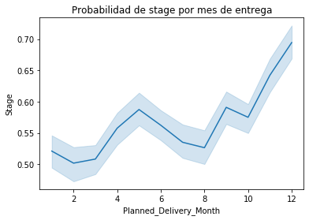

```python
sns.lineplot(x=dates_analysis['Planned_Delivery_Month'], y=dates_analysis['Stage'])
plt.title("Probabilidad de stage por mes de entrega")
plt.show()
```

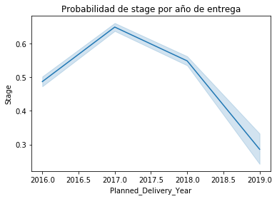

```python
sns.lineplot(x=dates_analysis['Planned_Delivery_Year'], y=dates_analysis['Stage'])
plt.title("Probabilidad de stage por año de entrega")
plt.show()
```

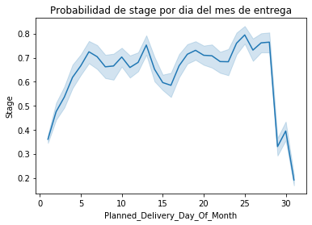

```python
sns.lineplot(x=dates_analysis['Planned_Delivery_Day_Of_Month'], y=dates_analysis['Stage'])
plt.title("Probabilidad de stage por dia del mes de entrega")
plt.show()
```

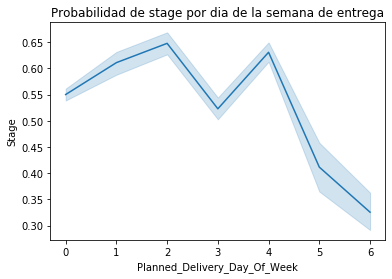

```python
sns.lineplot(x=dates_analysis['Planned_Delivery_Day_Of_Week'], y=dates_analysis['Stage'])
plt.title("Probabilidad de stage por dia de la semana de entrega")
plt.show()
```

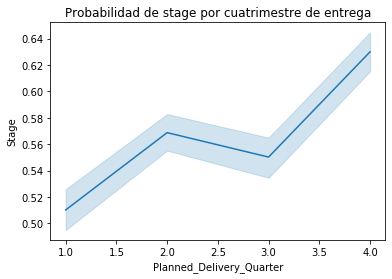

```python
sns.lineplot(x=dates_analysis['Planned_Delivery_Quarter'], y=dates_analysis['Stage'])
plt.title("Probabilidad de stage por cuatrimestre de entrega")
plt.show()
```

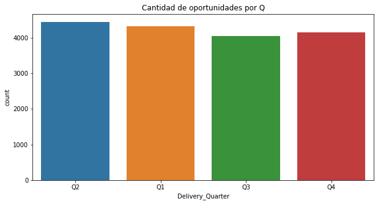

```python
plt.figure(figsize=(10,5))
sns.countplot(df.Delivery_Quarter)
plt.title("Cantidad de oportunidades por Q")
plt.show()
```

La cantidad de oportunidades se ecncuentra bien distribuida a lo largo de los distintos cuatrimestres, no se ve gran diferencia en CANTIDAD (mas allá de que terminen en Closed Lost o Closed Won). Año, mes y cuatrimestre parecen ser variables que van a influir. Cuatrimestre agrupa meses, asique al momento de construir los modelos habría que probar con una o la otra.